# REGRESSION AND MODEL VALIDATION

*This week I have learned to draw advanced scatterplots and some new things about the diagnostics of regressionmodel.*

```r
learning2014 <-read.csv("create_learning2014.csv", TRUE, ",")
summary(learning2014)
```

```
##       X.3              X.2              X.1               X
##  Min.   :  1.00   Min.   :  1.00   Min.   :  1.00   Min.   :  1.00
##  1st Qu.: 42.25   1st Qu.: 42.25   1st Qu.: 42.25   1st Qu.: 42.25
##  Median : 83.50   Median : 83.50   Median : 83.50   Median : 83.50
##  Mean   : 83.50   Mean   : 83.50   Mean   : 83.50   Mean   : 83.50
##  3rd Qu.:124.75   3rd Qu.:124.75   3rd Qu.:124.75   3rd Qu.:124.75
##  Max.   :166.00   Max.   :166.00   Max.   :166.00   Max.   :166.00
##  gender       Age           Attitude          deep            stra
##  F:110   Min.   :17.00   Min.   :1.400   Min.   :1.583   Min.   :1.250
##  M: 56   1st Qu.:21.00   1st Qu.:2.600   1st Qu.:3.333   1st Qu.:2.625
##          Median :22.00   Median :3.200   Median :3.667   Median :3.188
##          Mean   :25.51   Mean   :3.143   Mean   :3.680   Mean   :3.121
##          3rd Qu.:27.00   3rd Qu.:3.700   3rd Qu.:4.083   3rd Qu.:3.625
##          Max.   :55.00   Max.   :5.000   Max.   :4.917   Max.   :5.000
##       surf           Points
##  Min.   :1.583   Min.   : 7.00
##  1st Qu.:2.417   1st Qu.:19.00
##  Median :2.833   Median :23.00
##  Mean   :2.787   Mean   :22.72
##  3rd Qu.:3.167   3rd Qu.:27.75
##  Max.   :4.333   Max.   :33.00
```

This data includes 166 observations and seven variables, witch are gender, age, attitude (towards statistics) and three different studyingstrategies -or skills; deep, surface and strategic. The data includes also the exam points -variable, whitch we consider here the indicator of learning statistics.

**VISUALIZING THE DATA**

**Plot matrix of the variables**

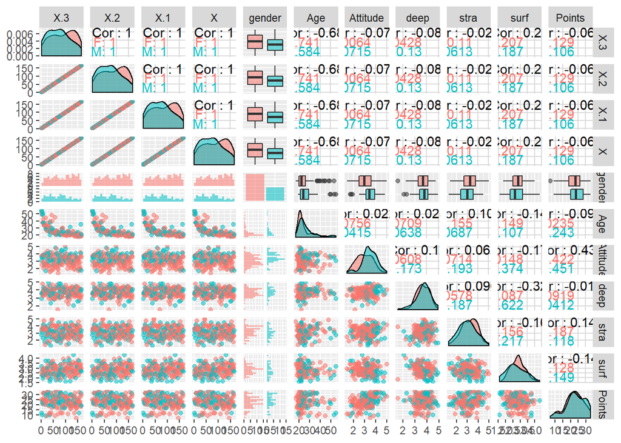

```r
visual_d <- ggpairs(learning2014, mapping = aes(col = gender, alpha = 0.3), lower = list(combo = wrap("facethist", bins = 20)))
visual_d
```

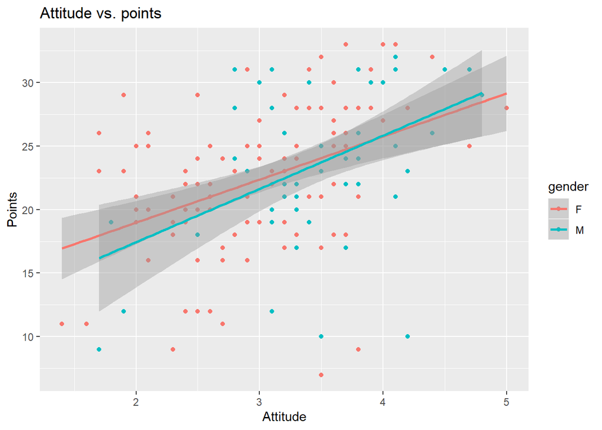

```r
pa <- ggplot(learning2014, aes(x = Attitude, y = Points, col = gender))
pat <- pa + geom_point()
patt <-pat + geom_smooth(method = "lm")
patti <-patt + ggtitle("Attitude vs. points")
patti
```

There seems to be a positive connection between attitude and points.

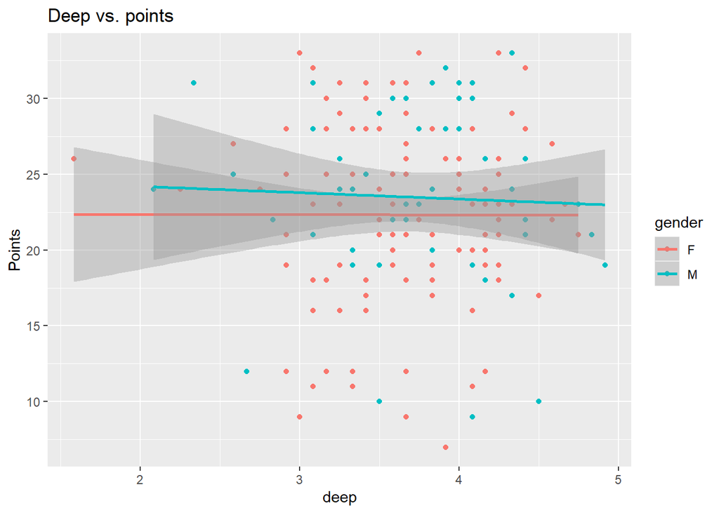

```r
pd <- ggplot(learning2014, aes(x = deep, y = Points, col = gender))
pde <- pd + geom_point()
pdee <- pde + geom_smooth(method = "lm")
pdeep <- pdee + ggtitle("Deep vs. points")
pdeep
```

There seems to be absolutely no connection between deep and points.

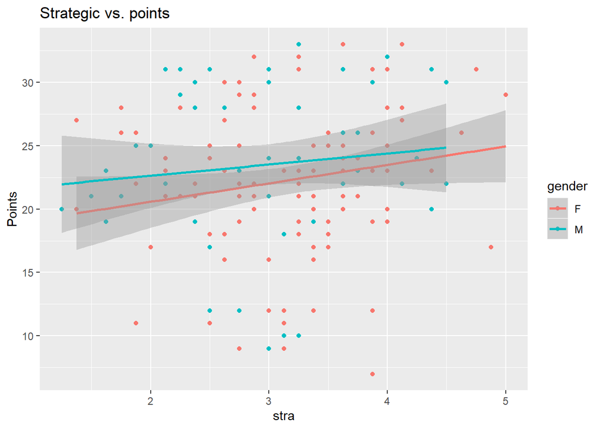

```r
pst <- ggplot(learning2014, aes(x = stra, y = Points, col = gender))
pstr <- pst + geom_point()
pstra <- pstr + geom_smooth(method = "lm")
pstrat <- pstra + ggtitle("Strategic vs. points")
pstrat
```

There might be a small positive connection between strategic and points.